# Venezia High Waters EDA

Luis Bronchal

### Summary

This is a first Exploratory Data Analisys for the aggregated data of Venezia High Waters. Original data come from [Centro Previsioni e Segnalazioni Maree](http://www.comune.venezia.it/archivio/25419)

### Checking the data

```r
library(TSA)
library(xts)
library(lubridate)
library(ggplot2)
library(forecast)
library(readr)
library(dplyr)
library(tidyr)
```

We load the data and check the its quality

```r
data <- read_csv(file = "../output/venezia.csv",
                 col_types = cols_only(col_datetime(), col_number()))

data_xts <- xts(order.by=data$datetime,
                      x=data$level)
attr(data_xts, 'frequency') <- 24
```

```r
first(data_xts)
```

[output not shown]

```r
end(data_xts)
```

```
## [1] "2016-01-01 UTC"
```

There are not any NA values:

```r
anyNA(data_xts)
```

```
## [1] FALSE
```

We look if there are duplicated:

```r
dup <- duplicated(index(data_xts), fromLast=TRUE)
sum(dup)
```

```
## [1] 5
```

We look what the duplicated values are:

```r
data_xts[index(data_xts[dup,])]
```

```
##            [,1]
## 1999-01-01   39
## 1999-01-01   57
## 2005-09-06   56
## 2005-09-06   54
## 2008-01-01    2
## 2008-01-01    1
## 2010-09-06   19
## 2010-09-06   37
## 2011-09-06    8
## 2011-09-06   -1
```

```r
data_xts <- data_xts[!dup]
```

We look for holes in the data

```r
data_xts_index <- index(data_xts)
all_points <- seq(first(data_xts_index), last(data_xts_index), by="hour")

# it looks like there are holes in the data
length(all_points) == length(index(data_xts))
```

```
## [1] FALSE
```

```r
# we complete the holes with the previous observation value
venezia_xts <- xts(order.by=all_points)
venezia_xts <- merge(data_xts, venezia_xts, join = "right")
venezia_xts <- na.locf(venezia_xts)
length(all_points) == length(index(venezia_xts))
```

```
## [1] TRUE
```

### Exploratory Data Analysis

The historical minimum and maximum level:

```r
range(venezia_xts)
```

```
## [1] -92 159
```

The mean level:

```r
mean(venezia_xts)
```

```
## [1] 25.8835
```

We take a look to some graphs

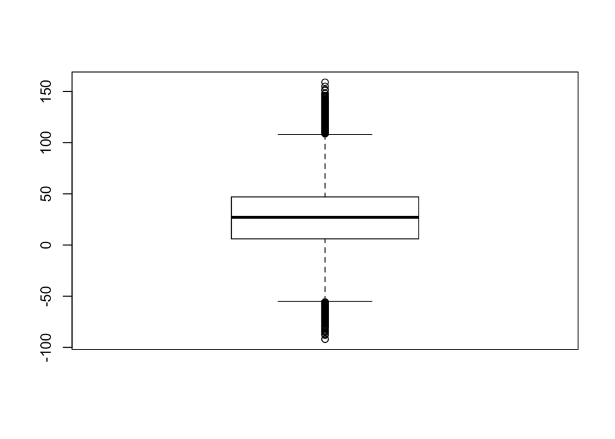

```r
boxplot(coredata(venezia_xts))
```

To plot all the data is confusing

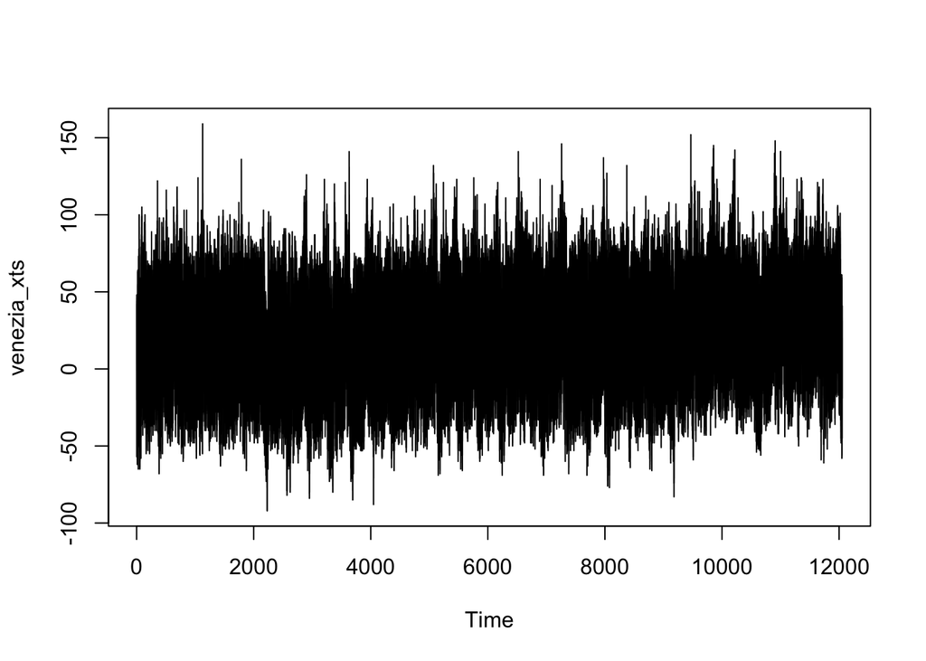

```r
ts.plot(venezia_xts)
```

Let’s see one month:

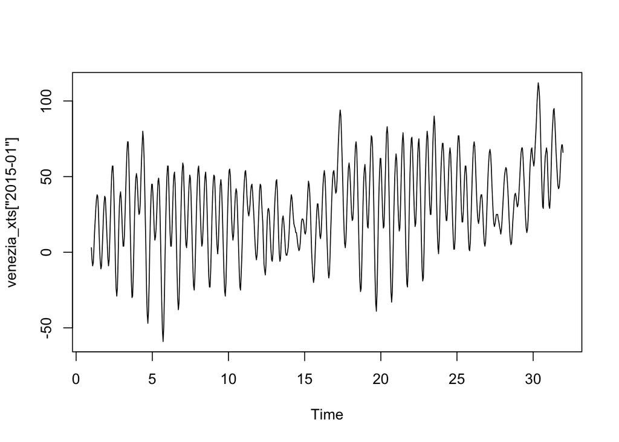

```r
ts.plot(venezia_xts["2015-01"])
```

```r
# compute the Fourier Transform
p <- periodogram(venezia_xts)
```

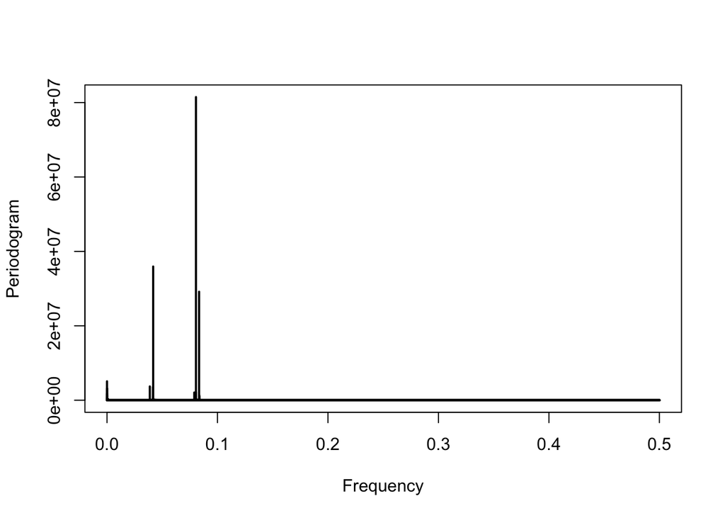

```r
dd <- data.frame(freq=p$freq, spec=p$spec, time=1/p$freq)
order <- dd[order(-dd$spec),]
top10 <- head(order, 10)
top10
```

```
##               freq     spec         time
## 23477 8.051097e-02 81476323     12.42067
## 12183 4.177984e-02 35927714     23.93499
## 24300 8.333333e-02 29160876     12.00000
## 1     3.429355e-06  5078354 291600.00000
## 12184 4.178326e-02  5022621     23.93303
## 11294 3.873114e-02  3697719     25.81902
## 12117 4.155350e-02  3550144     24.06536
## 33    1.131687e-04  3149139   8836.36364
## 12185 4.178669e-02  2716949     23.93106
## 23478 8.051440e-02  2163311     12.42014
```

```r
# references:
# https://anomaly.io/detect-seasonality-using-fourier-transform-r/
# http://rpubs.com/sinhrks/plot_tsstats
#
```

The main frequencies are around each 12 and 24 hours.

```r
data2 <- as.data.frame(venezia_xts)
data2$datetime <- rownames(data2)
rownames(data2) <- NULL
names(data2) <- c("level", "datetime")

data2$year <- year(data2$datetime)
data2$month <- month(data2$datetime)
data2$day <- day(data2$datetime)
data2$weekday <- factor(wday(data2$datetime), levels=1:7, labels=c("Monday", "Tuesday", "Wednesday", "Thursday", "Friday" , "Saturday", "Sunday"))
data2$hour <- hour(data2$datetime)
data2 <- data2[c("datetime", "year", "month", "day", "weekday", "level")]
```

We remove 2016 data because it has only 1 observation (first hour of the first day)

```r
data2 <- data2 %>% filter(year<2016)
```

We see the variation of the water levels through years. It looks like there are some kind of oscilation where some years have higher levels

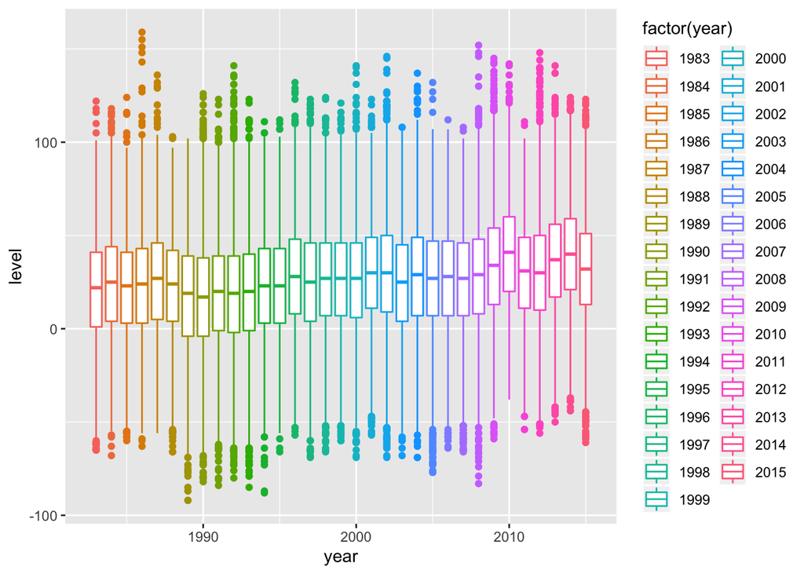

```r
# per year
ggplot(data2, aes(x=year, y=level, group=year, col=factor(year))) + geom_boxplot()
```

If we look it monthly, it looks like the months with low level are January, February and March

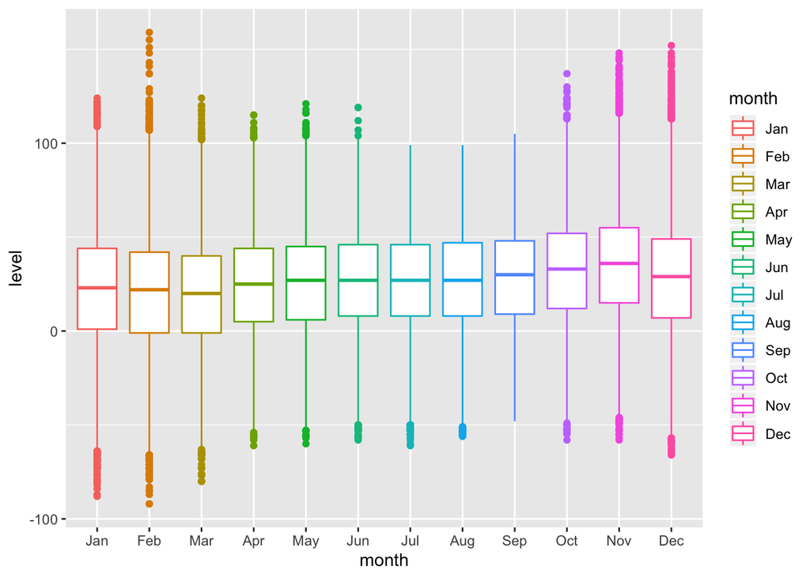

```r
# per month
ggplot(data2, aes(x=as.factor(month), y=level, group=month, col=as.factor(month))) + geom_boxplot() + scale_color_discrete("month", labels=month.abb) +
  scale_x_discrete("month", labels=month.abb)
```

It looks like there are not great variations if we consider the day of the week:

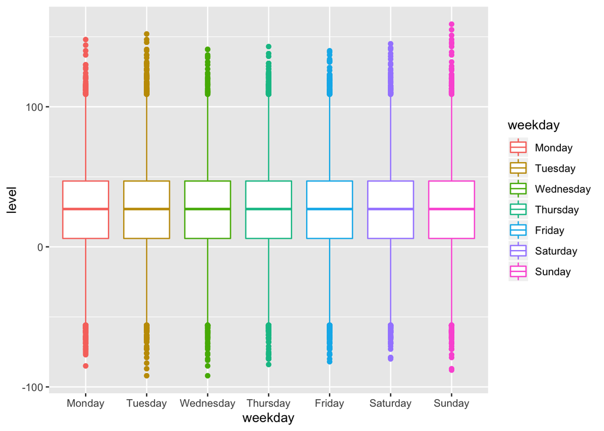

```r
# per weekday
ggplot(data2, aes(x=weekday, y=level, group=weekday, col=weekday)) + geom_boxplot()
```

```r
data_yearly <- data2 %>% group_by(year) %>%
  summarise(max=max(level), min=min(level), mean=mean(level)) %>%
  gather(key, value, -year)
```

It looks like there is an increase in the mean level year after year:

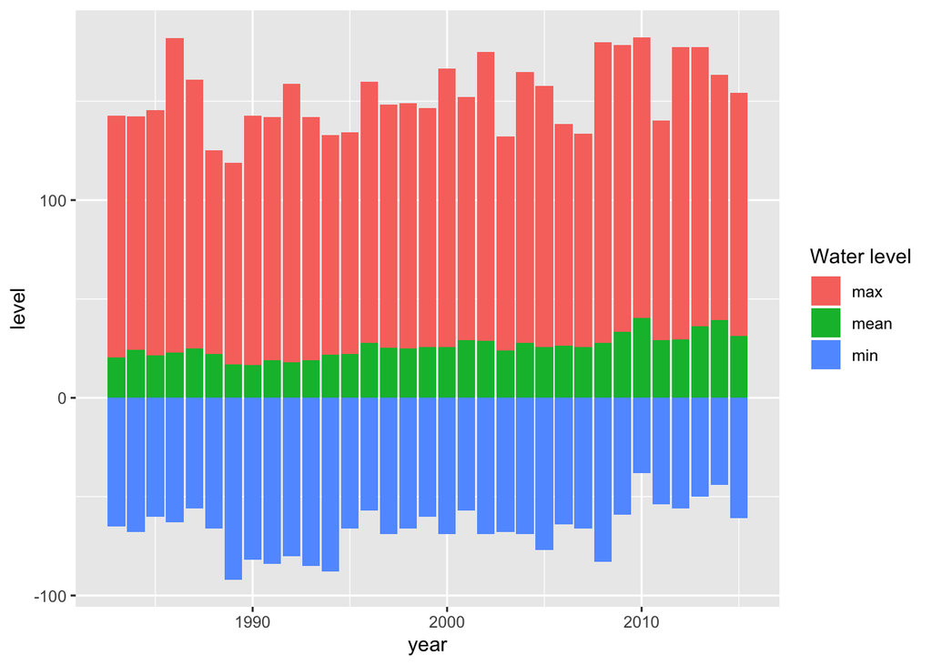

```r
data_yearly %>% ggplot(aes(x=year, y=value, fill=as.factor(key))) + geom_bar(stat="identity") +
  scale_fill_discrete("Water level") + scale_y_continuous("level")
```

If we calculate linear regresion it looks like there is an increase in the max and min level also year after year.

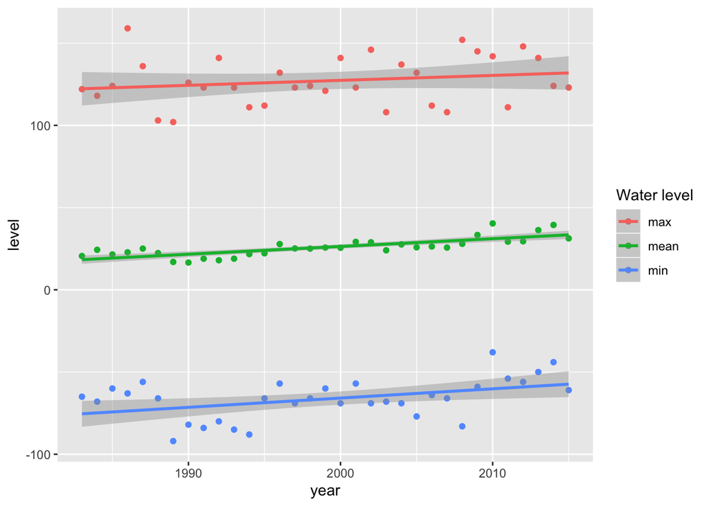

```r
data_yearly %>% ggplot(aes(x=year, y=value, col=as.factor(key))) + geom_point() +
  geom_smooth(method="lm") + scale_color_discrete("Water level") +
  scale_y_continuous("level")
```